# Machine Learning: Classification: Nearest Neighbours

```python
import numpy as np
# provides a multidimensional array object and routines for fast operations

import pandas as pd
# flexible data analysis

import matplotlib.pyplot as plt
# collection of functions that make matplotlib work like MATLAB
# matplotlib is a comprehensive library for creating visualisations

import seaborn as sns
# data visualisation library based on matplotlib

import plotly
import plotly.express as px
# contains functions for interactive figures
```

```python
import sys # System-specific parameters and functions
print('Python: {}'.format(sys.version[:7]))

print('Numpy: {}'.format(np.__version__))
print('Pandas: {}'.format(pd.__version__))
print('Matplotlib: {}'.format(sys.modules[plt.__package__].__version__))
print('Seaborn: {}'.format(sns.__version__))
print('Plotly: {}'.format(plotly.__version__))
```

```
Python: 3.8.16
Numpy: 1.24.3
Pandas: 2.0.1
Matplotlib: 3.7.1
Seaborn: 0.12.2
Plotly: 5.14.1
```

# Data

```python
ticker_TS = pd.read_csv("ticker_TS.csv", index_col="Date")
ticker_df = pd.read_csv("ticker_info_df.csv")
```

### Normalise our data

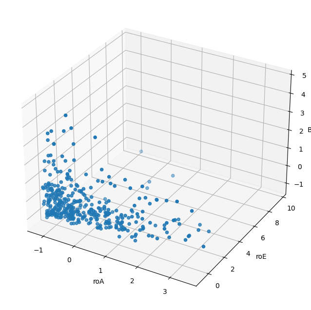

```python
from sklearn.preprocessing import StandardScaler

std_scaler = StandardScaler()

ticker_array_standard = std_scaler.fit_transform(ticker_df[["roA", "roE", "BVPS"]])

fig = plt.figure(figsize = (8,8))
ax = fig.add_subplot(projection='3d')

x = list(ticker_array_standard[:,0])
ax.set_xlabel("roA")
y = list(ticker_array_standard[:,1])
ax.set_ylabel("roE")
z = list(ticker_array_standard[:,2])
ax.set_zlabel("BVPS")

ax.scatter(x, y, z);
```

## Supervised Learning

### goal: learn from a labelled training set

#### s.t. resulting model can be effectively applied to unseen data

##### i.e. inferred function makes predictions based on the unseen data

##### e.g.

- Regression (e.g., forecast returns)
- Classification (e.g., predict the direction of returns)

# Classification

determine whether an output (that is categorical) belongs to a particular class or category

##### Linear Regression: (response is numerical)

$\hat{y} = (w^T \textbf{x} + b) = \left(\sum\limits_{i}w_ix_i + b\right)$

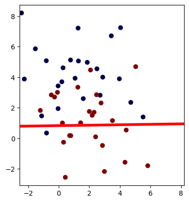

```python
from sklearn.datasets import make_blobs
X, y = make_blobs(centers=2, cluster_std=2, random_state=0, n_samples=50)

plt.figure()
plt.scatter(X[:, 0], X[:, 1], c=y, cmap = "seismic");

from sklearn.model_selection import train_test_split
X_train, X_test, y_train, y_test = train_test_split(X, y, stratify=y)

from sklearn.linear_model import LinearRegression
linreg = LinearRegression()
linreg.fit(X_train[:, :2], y_train)

coef = linreg.coef_.ravel()

line = np.linspace(X_train[:, 1].min(), X_train[:, 1].max())
line2 = line * coef[0]  + linreg.intercept_
plt.plot(line, line2, c='r', linewidth=4)
plt.gca().set_aspect("equal")
plt.xlim(min(line), max(line));
```

NB: "cmap" = "seismic"

- ref: https://matplotlib.org/stable/gallery/color/colormap_reference.html

##### Logisitic Regression: (response is categorical)

$\hat{y} = \text{sign}(w^T \textbf{x} + b) = \text{sign}\left(\sum\limits_{i}w_ix_i + b\right)$

i.e. decision boundary of a linear classifier = a hyperplane in the feature space

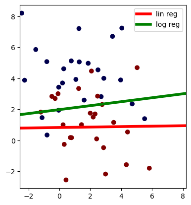

```python
plt.scatter(X[:, 0], X[:, 1], c=y, cmap = "seismic");

plt.plot(line, line2, c='r', linewidth=4, label = "lin reg")

from sklearn.linear_model import LogisticRegression
logreg = LogisticRegression()
logreg.fit(X_train[:, :2], y_train)

coef = logreg.coef_.ravel()

line = np.linspace(X_train[:, 1].min(), X_train[:, 1].max())
line3 = line * coef[0]  + logreg.intercept_
plt.plot(line, line3, c='g', linewidth=4, label = "log reg")
plt.gca().set_aspect("equal")
plt.xlim(min(line), max(line))
plt.legend();
```

# Nearest Neighbours

- rather than a logisitic regression, with Nearest Neighbours we will now consider points that are "near" each other as being similar
- we will utilsie proximity as the notion of distance:

#### $\text{argmin}_j || x_j - x||$

#### $d(x_{i}, x_{l}) = \sqrt{(x_{i1} - x_{l1})^2 + (x_{i2} - x_{l2})^2 + ... + (x_{ip} - x_{lp})^2}$

- this algorithm neglects a **lot** of information
- this algorithm is simple but does not help us understand the drivers

#### three new data points (marked by purple stars)

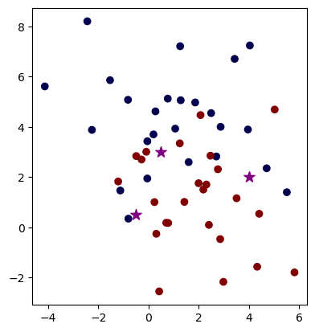

```python
plt.scatter(X[:, 0], X[:, 1], c=y, cmap = "seismic");
plt.gca().set_aspect("equal")

X_test = np.array([[0.5, 3], [4, 2], [-.5, .5]])
plt.scatter(X_test[:, 0], X_test[:, 1], c='purple', marker="*", s = 100);
```

#### the label of the new points determined by the closest “k” data point(s) in the training set

```python
from sklearn.metrics import euclidean_distances
from sklearn.neighbors import KNeighborsClassifier

def plot_n_neighbors(X, y, n_neighbors=1):

    X_test = np.array([[0.5, 3], [4, 2], [-.5, .5]])
    dist = euclidean_distances(X, X_test)
    closest = np.argsort(dist, axis=0)

    plt.figure()
    plt.gca().set_aspect("equal")
    for x, neighbors in zip(X_test, closest.T):
        for neighbor in neighbors[:n_neighbors]:
            plt.arrow(x[0], x[1], X[neighbor, 0] - x[0],
                    X[neighbor, 1] - x[1], head_width=0, fc='k', ec='k')

    clf = KNeighborsClassifier(n_neighbors=n_neighbors).fit(X, y)
    test_points = plt.scatter(X_test[:, 0], X_test[:, 1], c=clf.predict(X_test), marker="*", s = 100, cmap = "seismic")
    training_points = plt.scatter(X[:, 0], X[:, 1], c=y, cmap = "seismic")
```

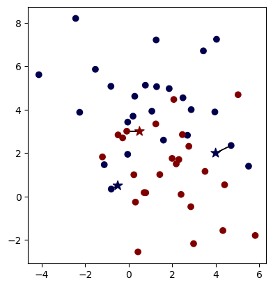

```python
plot_n_neighbors(X, y, n_neighbors=1) # k = 1
```

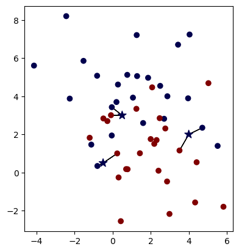

```python
plot_n_neighbors(X, y, n_neighbors=2) # k = 2
```

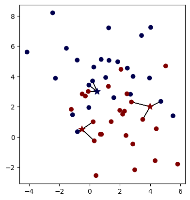

```python
plot_n_neighbors(X, y, n_neighbors=3) # k = 3
```

- predictions changing ! => so how to decide “k”???

```python
def plot_2d_classification(classifier, X, fill=False, ax=None, eps=None, alpha=1):
    # multiclass
    if eps is None:
        eps = X.std() / 2.

    if ax is None:
        ax = plt.gca()

    x_min, x_max = X[:, 0].min() - eps, X[:, 0].max() + eps
    y_min, y_max = X[:, 1].min() - eps, X[:, 1].max() + eps
    xx = np.linspace(x_min, x_max, 1000)
    yy = np.linspace(y_min, y_max, 1000)

    X1, X2 = np.meshgrid(xx, yy)
    X_grid = np.c_[X1.ravel(), X2.ravel()]
    decision_values = classifier.predict(X_grid)
    ax.imshow(decision_values.reshape(X1.shape), extent=(x_min, x_max,
                                                       y_min, y_max),
            aspect='auto', origin='lower', alpha=alpha, cmap = "coolwarm")
    ax.set_xlim(x_min, x_max)
    ax.set_ylim(y_min, y_max)
    ax.set_xticks(())
    ax.set_yticks(())
```

NB: "cmap" = "coolwarm"

- ref: https://matplotlib.org/stable/gallery/color/colormap_reference.html

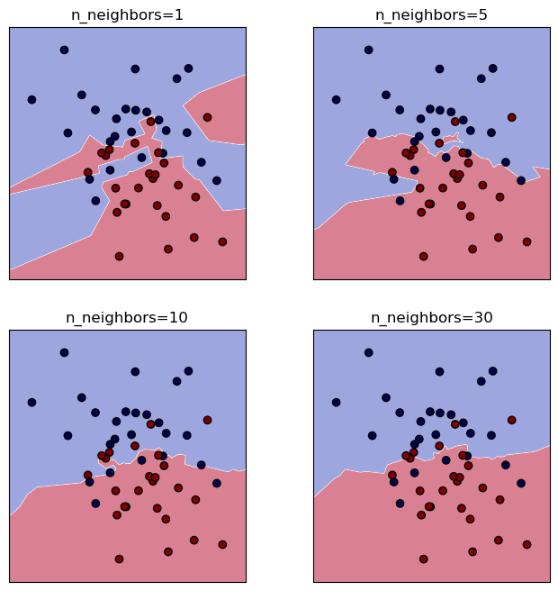

```python
fig, axes = plt.subplots(2, 2, figsize=(8, 8))
for ax, n_neighbors in zip(axes.ravel(), [1, 5, 10, 30]):
    ax.set_title(f"n_neighbors={n_neighbors}")
    clf = KNeighborsClassifier(n_neighbors=n_neighbors).fit(X, y)
    ax.scatter(X[:, 0], X[:, 1], c=y, edgecolor='k', cmap = "seismic")
    plot_2d_classification(clf, X, ax=ax, alpha=.5)
    ax.set_aspect("equal")
```

```python
# k = 1 => overfit / complex; k = 30 => decision boundary is simple, but many pts incorrectly labelled
```

k = small

- noise $\rightarrow$ $\uparrow$ influence on classificiation boundary
  - solution: lots of data needed (or reduce data via eg. PCA/feature selection)

k = large

- contrary to the principles of kNN: nearby points have similar classes
- computationally expensive